# Catatan Geomarketing

Sebuah Usaha untuk Menguasai

Ikang Fadhli

2022-09-23

# 1 Basic Knowledge GIS

## 1.1 Geographic Information Systems

Ada 4 fitur utama dari GIS, yakni:

1. Create geographic data.
2. Manage spatial data in a database.
3. Analyze and find patterns.
4. Map Visualization.

## 1.2 Well-Known Text (WKT)

WKT adalah *markup text* untuk *represent* objek *vector geometry*.

Ada tiga *markups*, yakni:

### 1.2.1 `POINT`

Misalkan `POINT(3 3)`

```r
data.frame(x = 3,
           y = 3) %>%
  ggplot(aes(x,y)) +
  geom_point() +
  xlim(0,6) +
  ylim(0,6) +
  theme_linedraw()
```

[figure not shown]

### 1.2.2 `LINESTRING`

Misalkan `LINESTRING (1 4, 3 3, 5 5)`

```r
ggplot() +
  annotate("segment",
           x = 1,
           y = 4,
           xend = 3,
           yend = 3) +
  annotate("segment",
           x = 3,
           y = 3,
           xend = 5,
           yend = 5) +
  geom_point(aes(x = 1,
                 y = 4)) +
  geom_point(aes(x = 3,
                 y = 3)) +
  geom_point(aes(x = 5,
                 y = 5)) +
  xlim(0,6) +
  ylim(0,6) +
  theme_linedraw()
```

[figure not shown]

### 1.2.3 `POLYGON`

Misalkan `POLYGON (1 4, 2 2, 4 1, 5 5, 1 4)`

```r
data.frame(x = c(1,2,4,5,1),
           y = c(4,2,1,5,4)) %>%
  ggplot() +
  annotate("segment",
           x = 1,
           y = 4,
           xend = 2,
           yend = 2) +
  annotate("segment",
           x = 2,
           y = 2,
           xend = 4,
           yend = 1) +
  annotate("segment",
           x = 4,
           y = 1,
           xend = 5,
           yend = 5) +
  annotate("segment",
           x = 5,
           y = 5,
           xend = 1,
           yend = 4) +
  geom_point(aes(x,y)) +
  xlim(0,6) +
  ylim(0,6) +
  theme_linedraw()
```

[figure not shown]

## 1.3 *Shapefiles*

Berikut adalah beberapa tipe file yang digunakan pada GIS, yakni:

```r
data.frame(
  tipe = c(".shp",".dbf",".prj",".shx"),
  features = c("shape format; the feature geometry",
               "attribute format; attributes for each shape, stored as two-dimensional table",
               "projection description, using a well-known text representation of coordinate reference systems",
               "shape index format; a positional index of the feature geometry to allow seeking forwards and backwards quickly")) %>%
  knitr::kable(caption = "Shapefiles")
```

Shapefiles

| tipe | features |
| --- | --- |
| .shp | shape format; the feature geometry |
| .dbf | attribute format; attributes for each shape, stored as two-dimensional table |
| .prj | projection description, using a well-known text representation of coordinate reference systems |
| .shx | shape index format; a positional index of the feature geometry to allow seeking forwards and backwards quickly |

## 1.4 *Libraries* yang Digunakan

```
install.packages("sf")
install.packages("dplyr")
install.packages("ggplot2")
library(sf)
library(dplyr)
library(ggplot2)
```

# 2 *Data Visualization with Maps*

## 2.1 Membuat *Maps*

Sekarang kita akan membuat *maps* dari data `GIS`. Data yang digunakan berasal dari `library(spData)`. Contoh:

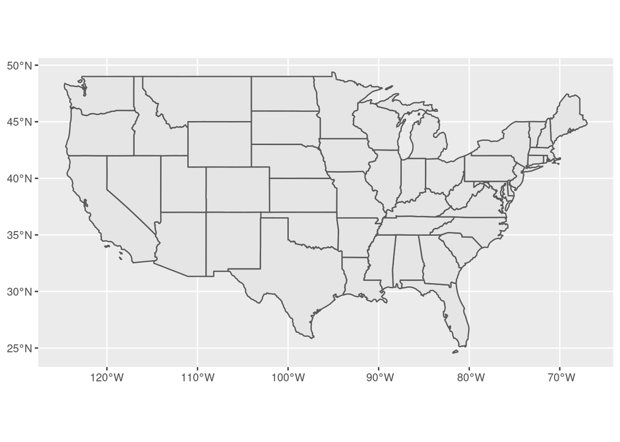

```r
library(spData)

ggplot(data = us_states) +
  geom_sf()
```

Sekarang kita coba lihat isi dari data `us_states` berikut ini:

```r
us_states
```

```
## Simple feature collection with 49 features and 6 fields
## Geometry type: MULTIPOLYGON
## Dimension:     XY
## Bounding box:  xmin: -124.7042 ymin: 24.55868 xmax: -66.9824 ymax: 49.38436
## Geodetic CRS:  NAD83
## First 10 features:
##    GEOID        NAME   REGION             AREA total_pop_10 total_pop_15
## 1     01     Alabama    South 133709.27 [km^2]      4712651      4830620
## 2     04     Arizona     West 295281.25 [km^2]      6246816      6641928
## 3     08    Colorado     West 269573.06 [km^2]      4887061      5278906
## 4     09 Connecticut Norteast  12976.59 [km^2]      3545837      3593222
## 5     12     Florida    South 151052.01 [km^2]     18511620     19645772
## 6     13     Georgia    South 152725.21 [km^2]      9468815     10006693
## 7     16       Idaho     West 216512.66 [km^2]      1526797      1616547
## 8     18     Indiana  Midwest  93648.40 [km^2]      6417398      6568645
## 9     20      Kansas  Midwest 213037.08 [km^2]      2809329      2892987
## 10    22   Louisiana    South 122345.76 [km^2]      4429940      4625253
##                          geometry
## 1  MULTIPOLYGON (((-88.20006 3...
## 2  MULTIPOLYGON (((-114.7196 3...
## 3  MULTIPOLYGON (((-109.0501 4...
## 4  MULTIPOLYGON (((-73.48731 4...
## 5  MULTIPOLYGON (((-81.81169 2...
## 6  MULTIPOLYGON (((-85.60516 3...
## 7  MULTIPOLYGON (((-116.916 45...
## 8  MULTIPOLYGON (((-87.52404 4...
## 9  MULTIPOLYGON (((-102.0517 4...
## 10 MULTIPOLYGON (((-92.01783 2...
```

```r
str(us_states)
```

```
## Classes 'sf' and 'data.frame':   49 obs. of  7 variables:
##  $ GEOID       : chr  "01" "04" "08" "09" ...
##  $ NAME        : chr  "Alabama" "Arizona" "Colorado" "Connecticut" ...
##  $ REGION      : Factor w/ 4 levels "Norteast","Midwest",..: 3 4 4 1 3 3 4 2 2 3 ...
##  $ AREA        : Units: [km^2] num  133709 295281 269573 12977 151052 ...
##  $ total_pop_10: num  4712651 6246816 4887061 3545837 18511620 ...
##  $ total_pop_15: num  4830620 6641928 5278906 3593222 19645772 ...
##  $ geometry    :sfc_MULTIPOLYGON of length 49; first list element: List of 1
##   ..$ :List of 1
##   .. ..$ : num [1:51, 1:2] -88.2 -88.2 -87.4 -86.9 -85.6 ...
##   ..- attr(*, "class")= chr [1:3] "XY" "MULTIPOLYGON" "sfg"
##  - attr(*, "sf_column")= chr "geometry"
##  - attr(*, "agr")= Factor w/ 3 levels "constant","aggregate",..: NA NA NA NA NA NA
##   ..- attr(*, "names")= chr [1:6] "GEOID" "NAME" "REGION" "AREA" ...
```

Terlihat ada dua tipe data, yakni: `sf` dan `data.frame`.

## 2.2 Membuat *Maps* dengan Label

Sekarang kita akan membuat maps dengan label sebagai pelengkap:

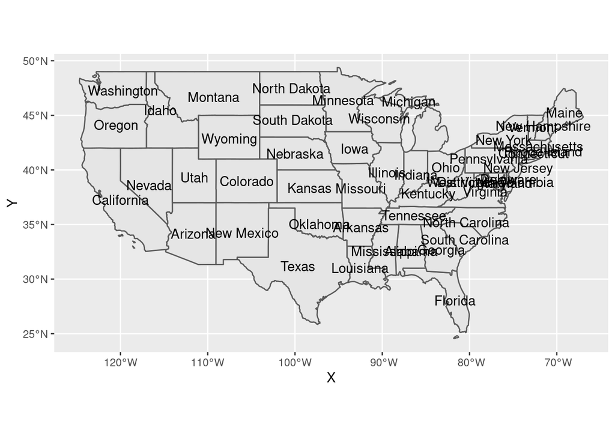

```r
ggplot(data = us_states) +
  geom_sf() +
  geom_sf_text(aes(label=NAME))
```

Karena bentuknya acak tak jelas, kita bisa pakai `repel` dengan cara meng-*install* terlebih dahulu dengan cara:

```
devtools::install_github("yutannihilation/ggsflabel")
library(ggsflabel)
```

Berikut adalah hasilnya:

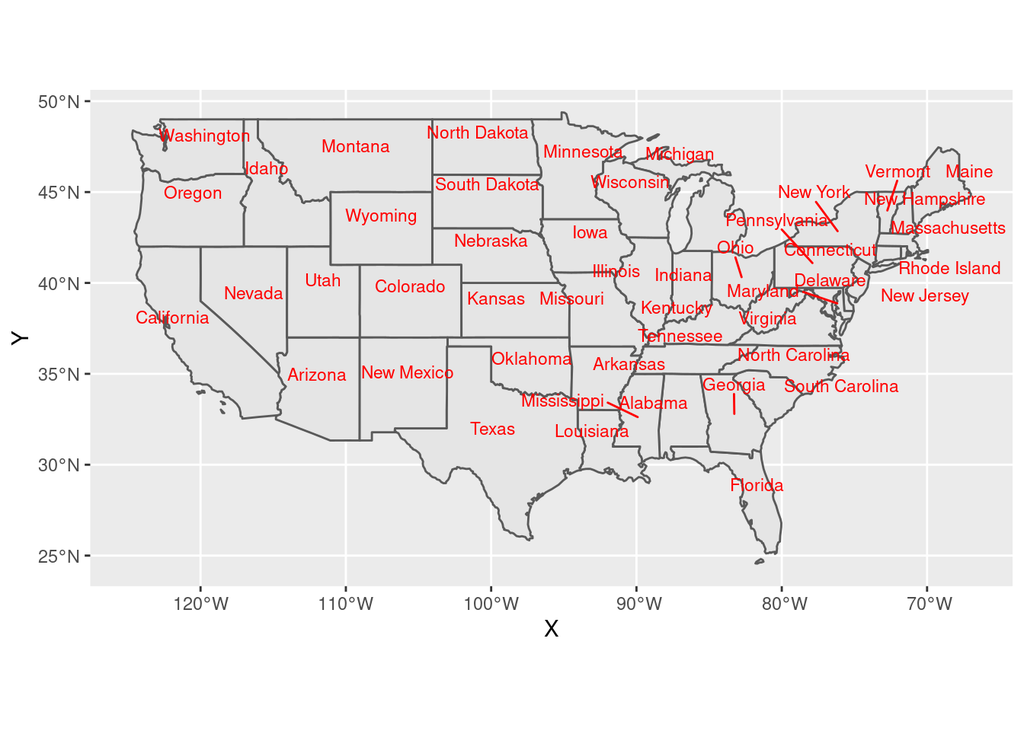

```r
ggplot(data = us_states) +
  geom_sf() +
  geom_sf_text_repel(aes(label=NAME),
                     nudge_y=0.5,
                     size=3,
                     color="red")
```

## 2.3 *Graduated Symbol Map*

Kita bisa menggunakan berbagai parameter untuk memodifikasi gambar *maps*.

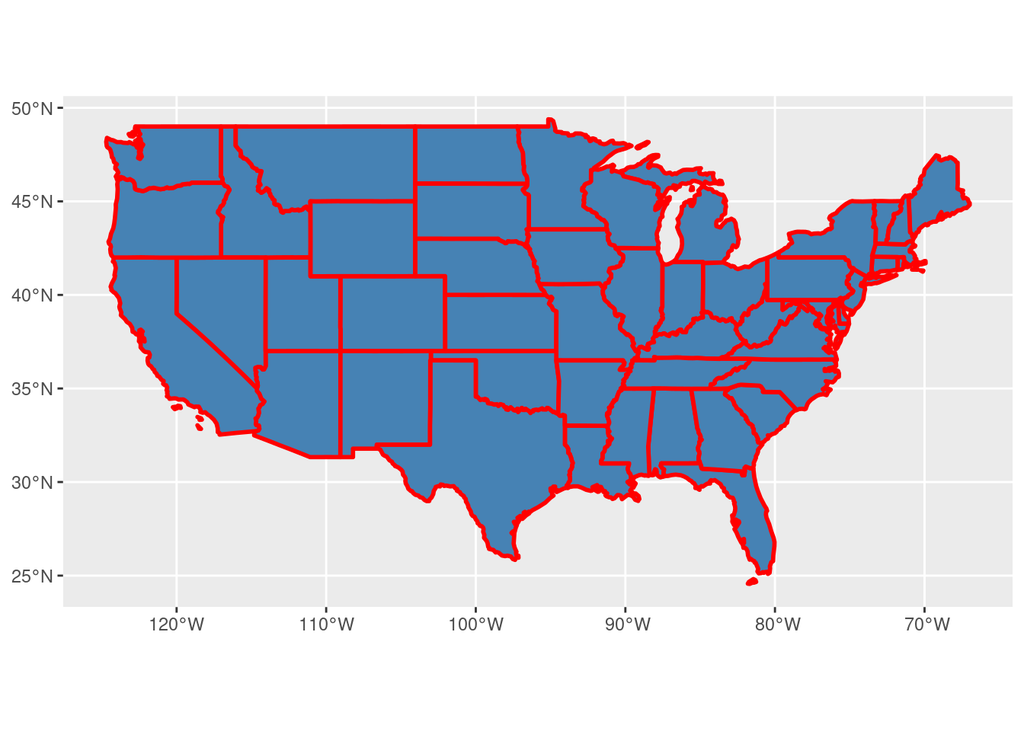

```r
ggplot(us_states)+
  geom_sf(fill = "steelblue",
          size = 1,
          color = "red")
```

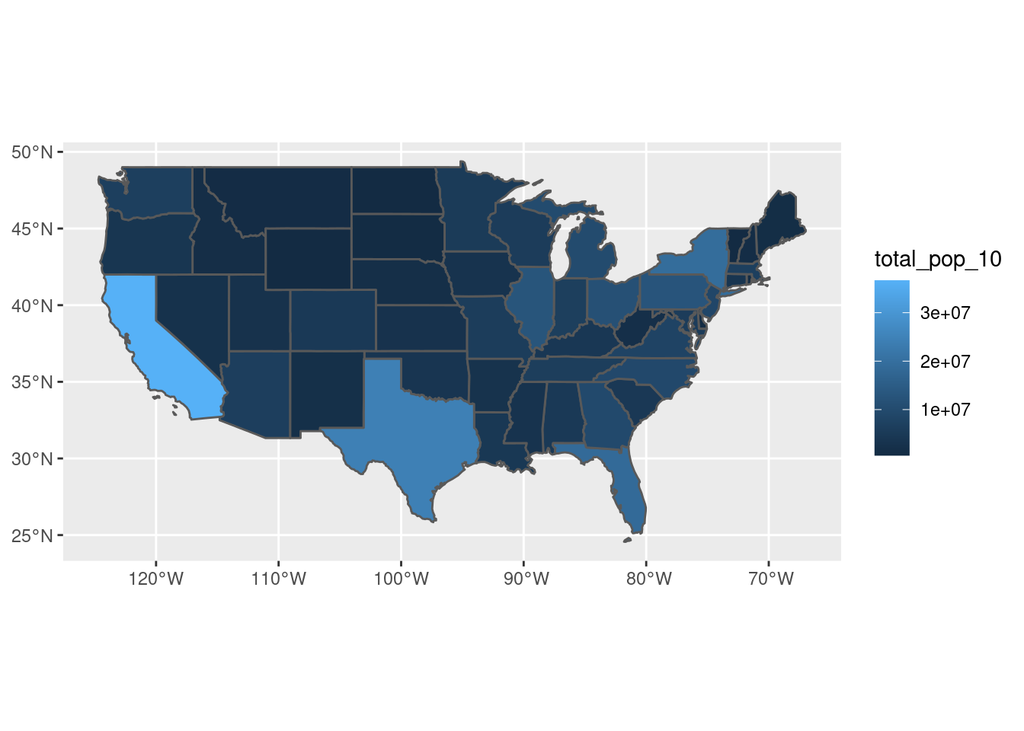

```r
ggplot(us_states)+
  geom_sf(aes(fill=total_pop_10))
```

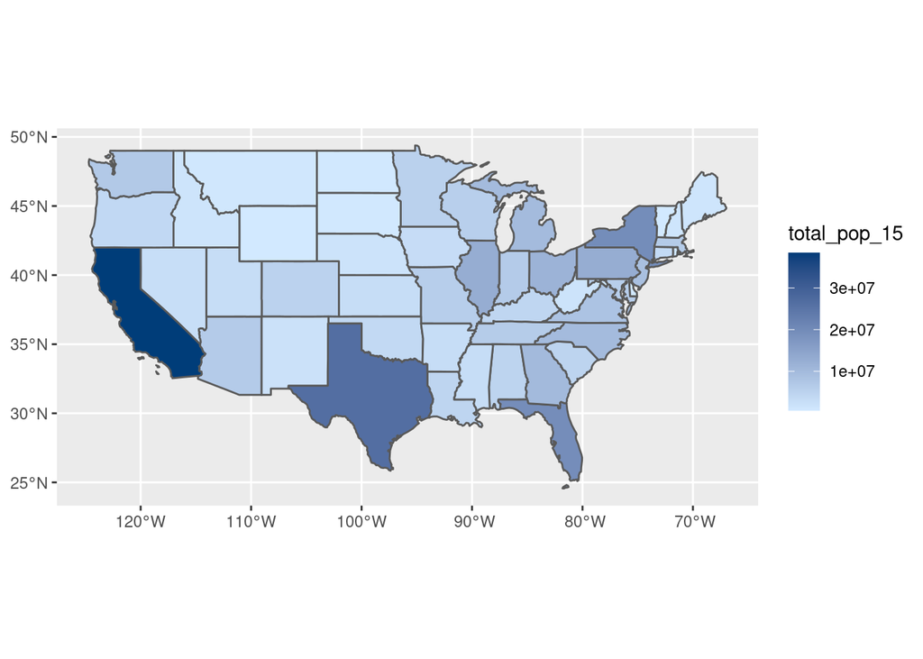

```r
ggplot(us_states)+
  geom_sf(aes(fill=total_pop_15))+
  scale_fill_continuous(low="#D2E9FF", high="#003D79")
```

## 2.4 *Basic Elements Maps*

Kita bisa melakukan *overlay maps* sama seperti `ggplot2`. Ini sebagai contoh data *New Zealand* dan kita *overlay* dengan top `101` titik tertinggi. Berikut adalah hasilnya:

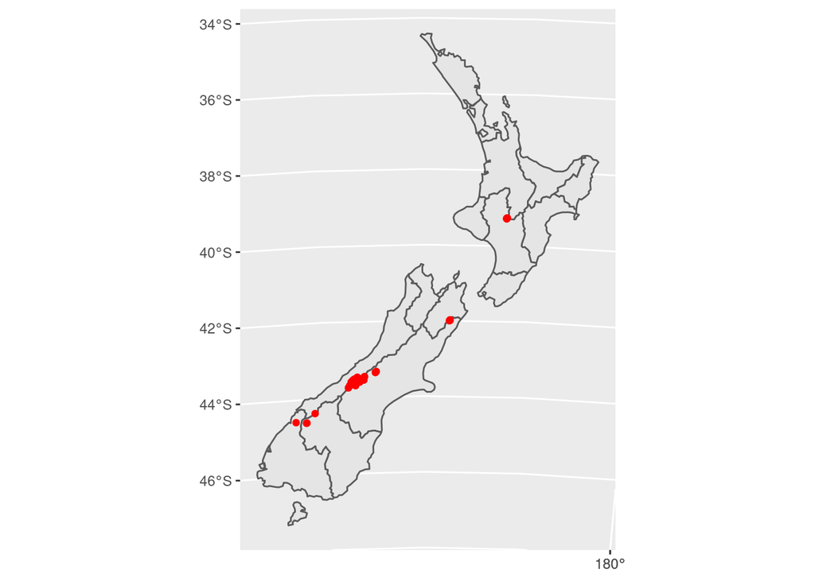

```r
ggplot() +
  geom_sf(data=nz) +
  geom_sf(data=nz_height, color="red")
```

### 2.4.1 Menambahkan *Arrow* dan Skala

Untuk menambahkan elemen peta, kita bisa menggunakan *library* baru ini:

```
install.packages("ggspatial")
library(ggspatial)
```

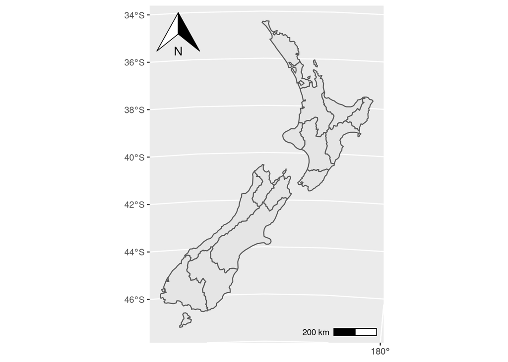

```r
ggplot()+
  geom_sf(data=nz)+
  annotation_scale(location="br")+
  annotation_north_arrow(location="tl")
```

### 2.4.2 Mengubah *Linetype* dan *Shape*

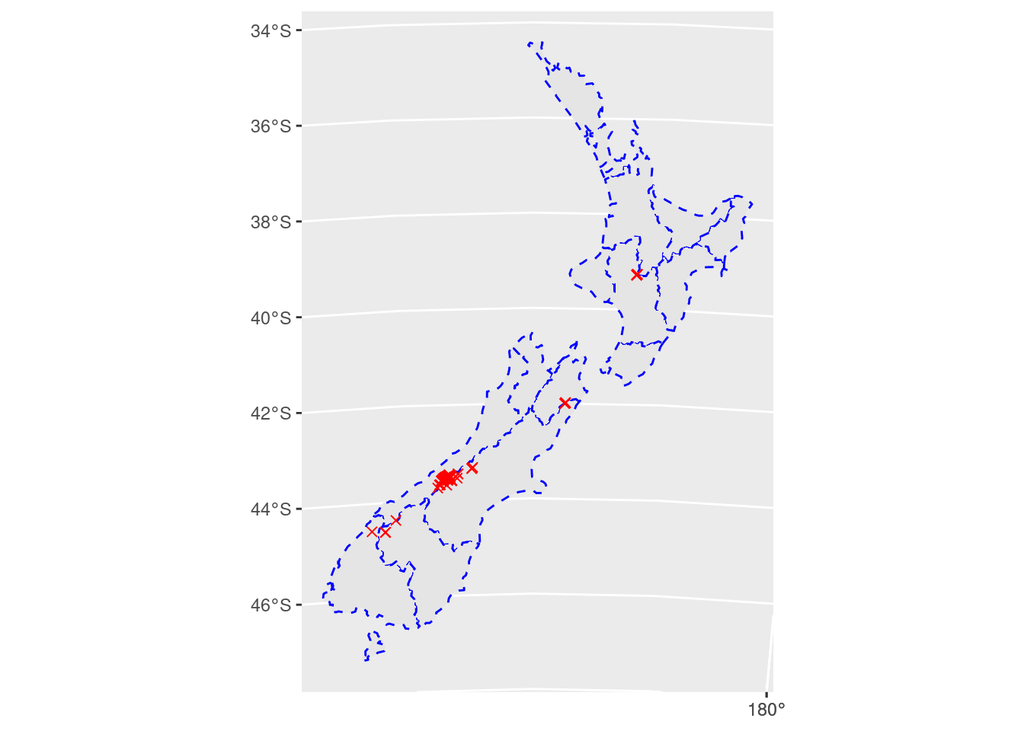

```r
ggplot() +
  geom_sf(data=nz, color="blue", linetype="dashed") +
  geom_sf(data=nz_height, color="red", size=2, shape=4)
```

Berikut adalah beberapa poin penting:

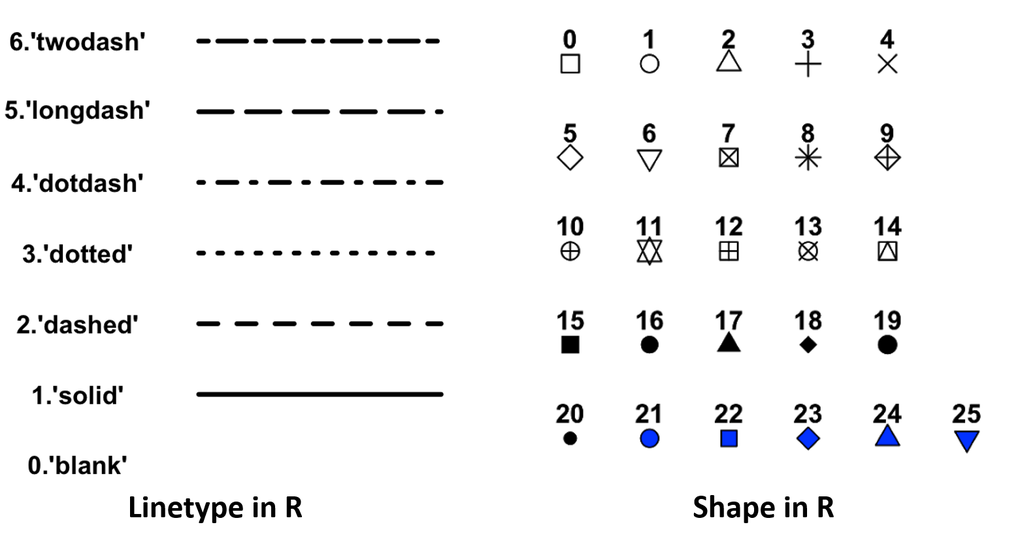

```r
knitr::include_graphics("download.png")
```

[*Some important publication*](https://rpubs.com/Chia-JungYEH/717514).

[*Another important publication*](https://geocompr.robinlovelace.net/adv-map.html)